# Classification and Description of Plant Communities Using Vegetation Monitoring Data from Cleveland Metroparks

Author: John Reinier

Last Updated: 2025-01-23

# Introduction

Vegetation classification is a critical component of natural resource management in a rapidly changing natural world. Climate change and pest and pathogen outbreaks are among a host of factors influencing the trajectory of plant communities across the world. In light of these influences, ecologists and land managers continue to grapple with how to manage resources in ways that ensure healthy, functioning ecosystems in the coming decades and beyond. In order to effectively manage for future conditions, it is important to understand past and present conditions. Individual species and species assemblages that characterize a healthy natural condition now, may not be ideal under future climate scenarios. A firm understanding of current composition and structure of natural areas is necessary for evaluating the extent to which conditions change. This is where vegetation classification becomes important. Ecosystem classification and description has a long history, particularly in the eastern United States. Early land surveyors were the first to note dominant species and describe conditions in virtually pristine natural areas as European settlement expanded across the country. Their observations serve as a baseline to measure departure from what we would consider an “undisturbed” state. These early records also helped inform the production of the first regional vegetation maps. It is those early descriptions and maps that are reminders of how much the natural landscape of the United States has changed since European settlement.

This investigation is the first attempt to use data from a long-term vegetation monitoring program at Cleveland Metroparks to classify and describe plant communities across the park district. It focuses on a classification resolution with broad applicability to management planning. It also provides a starting point for future investigation of finer-scale vegetation patterns. The results are applicable to the broader ecoregion(s) that Cleveland Metroparks’ properties occur in and will serve as an important baseline for studying changes in species composition and ecosystem function.

# Methods

## Study Area

[figure not shown]

## Data Collection

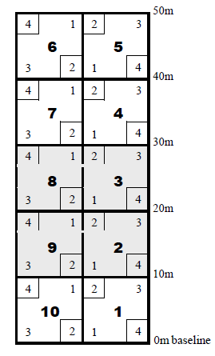

Data on woody species were collected in every quadrat within the plot. Each woody taxon encountered was identified to species level and a diameter at breast height measurement was taken. Each measurement was placed into one of the following diameter classes: 0-1cm, 1-2.5 cm, 2.5-5 cm, 5-10 cm, 10-15 cm, 15-20 cm, 20-25 cm, 25-30 cm, 30-35 cm, 35-40 cm. Any stem over 40 cm in diameter was recorded individually to the nearest 0.1 cm. Multi-stemmed shrub taxa were recorded as “shrub clump.”

- Environmental Data (in prep)
  - Soil chemical analyses
  - SSURGO soil texture (maybe)
  - Landfire topographic data
    - Sampled rasters in QGIS

## Statistical Analyses

#### Query data and create site X species matrix

```r
vibi.combined.new <- dbGetQuery(conn, "SELECT * FROM nr_misc.plot_data_for_veg_comm_analysis_newest_sample;")
vibi.combined.matrix.new <- cast(vibi.combined.new, plot_id ~ acronym, value='abundance', fun="mean")
row.names(vibi.combined.matrix.new) <- vibi.combined.matrix.new[ ,1]
vibi.combined.matrix.new[is.na(vibi.combined.matrix.new)] <- 0
```

#### Apply Hellinger transformation and calculate euclidean distance matrix

```r
vibi.combined.new.hell <- decostand(vibi.combined.matrix.new, "hel", margin = 1)
vibi.combined.new.hell.dist <- vegdist(vibi.combined.new.hell, "euc")
```

**The Hellinger Transformation**

This (above) is called the Hellinger transformation. The Euclidian distance function applied to Hellinger-transformed data produces a Hellinger distance matrix. Useful before PCA and RDA and K-means partitioning.

### Hierarchical Clustering (Exploratory)

### Indicator Species Analysis

### Nonmetric Multidimensional Scaling (NMDS)

# Results

### Hierarchical Clustering

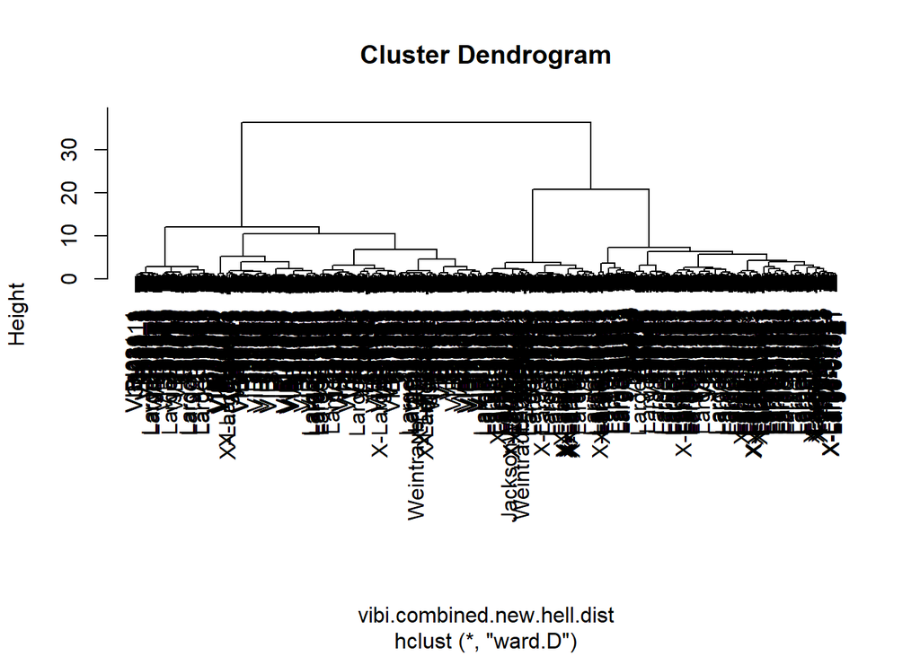

```r
vibi.combined.new.clust.ward.hell <- hclust(vibi.combined.new.hell.dist, method = "ward.D")
plot(vibi.combined.new.clust.ward.hell)
```

```r
## Cut the dendrogram at 8 groups
vibi.combined.cl.groups = cutree(vibi.combined.new.clust.ward.hell, k=8)
```

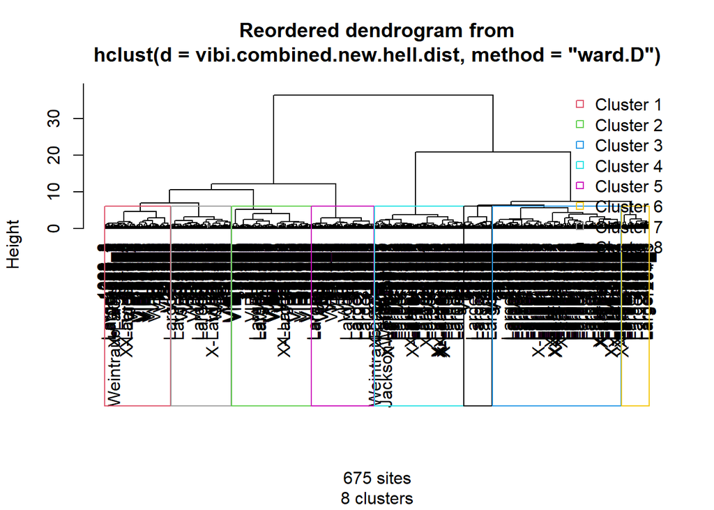

```r
source("hcoplot.R")
hcoplot(vibi.combined.new.clust.ward.hell, vibi.combined.new.hell.dist, k=8)
```

#### Consider looking at silhouette plot of the final partition

## K-means Partitioning

```r
vibi.combined.new.kmeans7 <- kmeans(vibi.combined.new.hell.dist, centers=7, nstart=100)
summary(vibi.combined.new.kmeans7)
```

#### Combine k-means clusters with plot matrix

```r
kmeans7_cluster <- vibi.combined.new.kmeans7$cluster
vibi.new.kmeans7.cluster <- cbind(vibi.combined.matrix.new, kmeans7_cluster)
```

## Indicator Species Analysis

```r
vibi.combined.new.kmeans7.indval.out = indval(vibi.combined.matrix.new[,c(-1)], vibi.combined.new.kmeans7$cluster, numitr=10000)
vibi.new.kmeans7.gr <- vibi.combined.new.kmeans7.indval.out$maxcls[vibi.combined.new.kmeans7.indval.out$pval <= 0.05]
vibi.new.kmeans7.iv <- vibi.combined.new.kmeans7.indval.out$indcls[vibi.combined.new.kmeans7.indval.out$pval <= 0.05]
vibi.new.kmeans7.pv <- vibi.combined.new.kmeans7.indval.out$pval[vibi.combined.new.kmeans7.indval.out$pval <= 0.05]
vibi.new.kmeans7.fr <- apply(vibi.combined.matrix.new[,c(-1)] > 0, 2, sum)[vibi.combined.new.kmeans7.indval.out$pval <= 0.05]
vibi.new.kmeans7.fidg <- data.frame(group=vibi.new.kmeans7.gr, indval=vibi.new.kmeans7.iv, pvalue=vibi.new.kmeans7.pv, freq=vibi.new.kmeans7.fr)
vibi.new.kmeans7.fidg <- vibi.new.kmeans7.fidg[order(vibi.new.kmeans7.fidg$group, -vibi.new.kmeans7.fidg$indval),]
```

## NMDS ordination

```r
vibi.combined.new.nmds <- metaMDS(vibi.combined.new.hell.dist, k = 2, try = 50, trymax = 100, autotransform=F)
```

#### Let’s plot it and see how the groups look

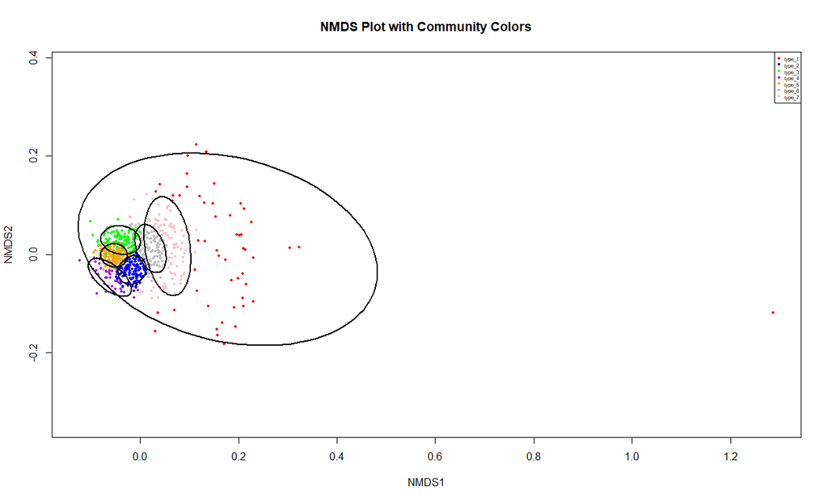

```r
vibi.combined.new.grp.lev <- factor(vibi.new.kmeans7.cluster$kmeans7_cluster)
col <- c("red", "blue", "green", "purple", "orange", "gray", "pink")
sit.sc <- vegan::scores(vibi.combined.new.nmds, display="sites")
p <- ordiplot(vibi.combined.new.nmds, type="none", main="NMDS Plot with Community Colors", choices=c(1,2))
points(sit.sc, pch=20, cex=0.8, col=col[vibi.combined.new.grp.lev], bg=col[vibi.combined.new.grp.lev])
ordiellipse(vibi.combined.new.nmds, vibi.combined.new.grp.lev, kind = "sd", conf=0.80, lwd=2, col="black")
leg.txt <- c("type_1", "type_2", "type_3", "type_4", "type_5", "type_6", "type_7")

legend("topright", leg.txt,
       pch=20, col=col[], pt.cex=0.75, cex=0.50)
```

#### The meadow plots are highly variable and messy. Let’s remove them and run the analysis again.

```r
vibi.combined.new.matrix.no.meadows <- vibi.new.kmeans7.cluster[which (vibi.new.kmeans7.cluster$kmeans7_cluster %in% c(2:7)),]
vibi.combined.new.matrix.no.meadows <- vibi.combined.new.matrix.no.meadows[,c(-1,-919)]
vibi.combined.new.matrix.no.meadows <- vibi.combined.new.matrix.no.meadows[, colSums(vibi.combined.new.matrix.no.meadows != 0) > 0]
```

#### Apply Hellinger standardization and create euclidean distance matrix

```r
vibi.combined.new.hell.forest <- decostand(vibi.combined.new.matrix.no.meadows, "hel", margin = 1)
vibi.combined.new.hell.forest.dist <- vegdist(vibi.combined.new.hell.forest, "euc")
```

#### K-means Partitioning

```r
vibi.combined.new.forest.kmeans6 <- kmeans(vibi.combined.new.hell.forest.dist, centers=6, nstart=100)
```

#### Combine k-means clusters with plot matrix

```r
kmeans6.forest.cluster <- vibi.combined.new.forest.kmeans6$cluster
vibi.combined.new.forest.kmeans6.cluster <- cbind(vibi.combined.new.matrix.no.meadows, kmeans6.forest.cluster)
```

#### Run Indicator Species Analysis to see which species are significant indicators of each group

```r
vibi.combined.new.forest.kmeans6.indval.out = indval(vibi.combined.new.matrix.no.meadows, vibi.combined.new.forest.kmeans6$cluster, numitr=10000)
vibi.new.forest.kmeans6.gr <- vibi.combined.new.forest.kmeans6.indval.out$maxcls[vibi.combined.new.forest.kmeans6.indval.out$pval <= 0.05]
vibi.new.forest.kmeans6.iv <- vibi.combined.new.forest.kmeans6.indval.out$indcls[vibi.combined.new.forest.kmeans6.indval.out$pval <= 0.05]
vibi.new.forest.kmeans6.pv <- vibi.combined.new.forest.kmeans6.indval.out$pval[vibi.combined.new.forest.kmeans6.indval.out$pval <= 0.05]
vibi.new.forest.kmeans6.fr <- apply(vibi.combined.new.matrix.no.meadows > 0, 2, sum)[vibi.combined.new.forest.kmeans6.indval.out$pval <= 0.05]
vibi.new.forest.kmeans6.fidg <- data.frame(group=vibi.new.forest.kmeans6.gr, indval=vibi.new.forest.kmeans6.iv, pvalue=vibi.new.forest.kmeans6.pv, freq=vibi.new.forest.kmeans6.fr)
vibi.new.forest.kmeans6.fidg <- vibi.new.forest.kmeans6.fidg[order(vibi.new.forest.kmeans6.fidg$group, -vibi.new.forest.kmeans6.fidg$indval),]
```

```r
vibi.combined.new.forest.nmds <- metaMDS(vibi.combined.new.hell.forest.dist, k = 2, try = 50, trymax = 100, autotransform=F)
```

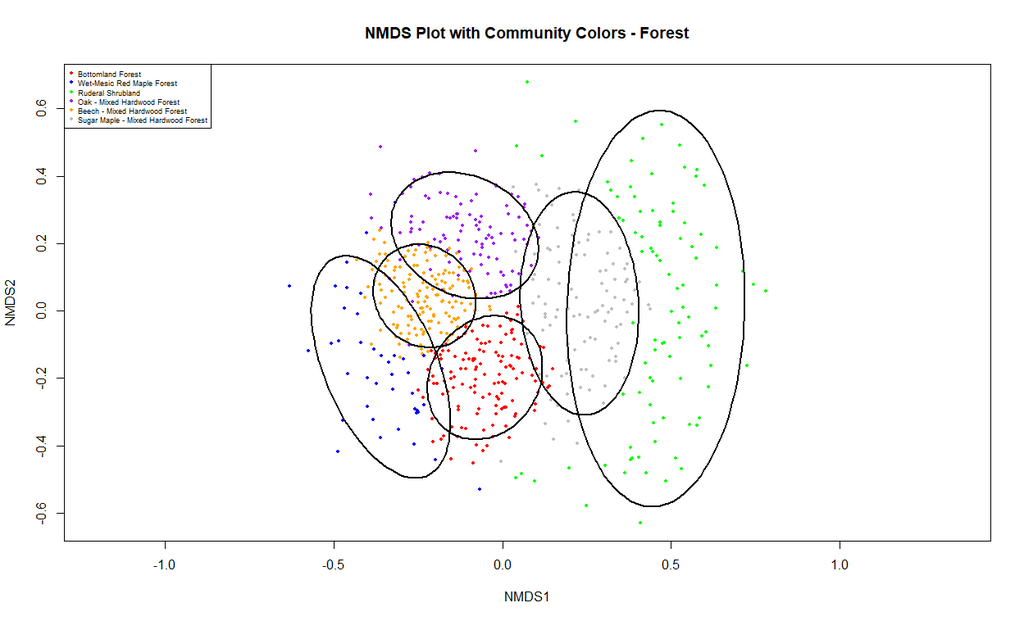

```r
vibi.combined.new.forest.grp.lev <- factor(vibi.combined.new.forest.kmeans6.cluster$kmeans6.forest.cluster)
col <- c("red", "blue", "green", "purple", "orange", "gray")
sit.sc <- vegan::scores(vibi.combined.new.forest.nmds, display="sites")
p <- ordiplot(vibi.combined.new.forest.nmds, type="none", main="NMDS Plot with Community Colors - Forest", choices=c(1,2))
points(sit.sc, pch=20, cex=0.8, col=col[vibi.combined.new.forest.grp.lev], bg=col[vibi.combined.new.forest.grp.lev])
ordiellipse(vibi.combined.new.forest.nmds, vibi.combined.new.forest.grp.lev, kind = "sd", conf=0.80, lwd=2, col="black")
leg.txt <- c("Bottomland Forest", "Wet-Mesic Red Maple Forest", "Ruderal Shrubland", "Oak - Mixed Hardwood Forest", "Beech - Mixed Hardwood Forest", "Sugar Maple - Mixed Hardwood Forest")

legend("topleft", leg.txt,
       pch=20, col=col[], pt.cex=0.75, cex=0.58)
```

#### Okay, things get a little clearer with the meadow plots excluded.

#### Try to fit some environmental data

#### Query environmental variables

```r
vibi.env <- dbGetQuery(conn, "SELECT * FROM nr_misc.env_data_for_veg_comm_analysis;")
row.names(vibi.env) <- vibi.env[ ,1]
vibi.env[is.na(vibi.env)] <- 0
```

#### Filter site X species matrix to include only plots with env data

```r
vibi.forest.sub.env <- filter(vibi.combined.new.matrix.no.meadows, rownames(vibi.combined.new.matrix.no.meadows) %in% vibi.env$plot_id)
```

#### Apply Hellinger standardization and create euclidean distance matrix

```r
vibi.forest.sub.env.hell <- decostand(vibi.forest.sub.env, "hel", margin = 1)
vibi.forest.sub.env.hell.dist <- vegdist(vibi.forest.sub.env.hell, "euc")
```

#### Combine with forest group ID from ealrier K-means clustering

```r
vibi.forest.sub.env.grp <- merge(vibi.forest.sub.env, vibi.combined.new.forest.kmeans6.cluster["kmeans6.forest.cluster"], by.x = 'row.names', by.y = 'row.names')
row.names(vibi.forest.sub.env.grp) <- vibi.forest.sub.env.grp[ ,1]
vibi.forest.sub.env.grp <- vibi.forest.sub.env.grp[,-1]
```

#### Re-run the NMDS ordiantion with only those plots we have environmental data for

```r
vibi.forest.sub.env.nmds <- metaMDS(vibi.forest.sub.env.hell.dist, k = 2, try = 50, trymax = 100, autotransform=F)
```

#### Standardize env variables since they are on different scales

```r
vibi.env.std <- decostand(vibi.env[,2:20], "standardize")
```

#### Filter to only include plots included in NMDS

```r
vibi.forest.env.std <- filter(vibi.env.std, rownames(vibi.env.std) %in% rownames(vibi.forest.sub.env.grp))
```

#### Plot new NMDS with env vectors

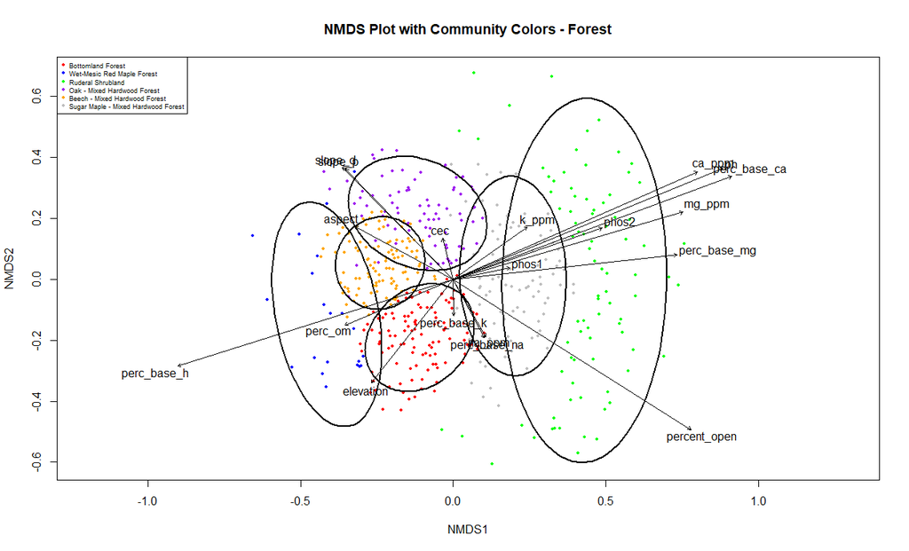

```r
vibi.forest.sub.env.grp.lev <- factor(vibi.forest.sub.env.grp$kmeans6.forest.cluster)
col <- c("red", "blue", "green", "purple", "orange", "gray")
sit.sc <- vegan::scores(vibi.forest.sub.env.nmds, display="sites")
p <- ordiplot(vibi.forest.sub.env.nmds, type="none", main="NMDS Plot with Community Colors - Forest", choices=c(1,2))
points(sit.sc, pch=20, cex=0.8, col=col[vibi.forest.sub.env.grp.lev], bg=col[vibi.forest.sub.env.grp.lev])
ordiellipse(vibi.forest.sub.env.nmds, vibi.forest.sub.env.grp.lev, kind = "sd", conf=0.80, lwd=2, col="black")
leg.txt <- c("Bottomland Forest", "Wet-Mesic Red Maple Forest", "Ruderal Shrubland", "Oak - Mixed Hardwood Forest", "Beech - Mixed Hardwood Forest", "Sugar Maple - Mixed Hardwood Forest")

legend("topleft", leg.txt,
       pch=20, col=col[], pt.cex=0.75, cex=0.58)
vibi.forest.env.fit <- envfit(vibi.forest.sub.env.nmds, vibi.forest.env.std, permu = 999, p.max = 0.01, choices = c(1, 2))
plot(vibi.forest.env.fit, col = "black", font=1)
```

#### Another plot but cleaned up a little (i.e., removed some clearly redundant env variables)

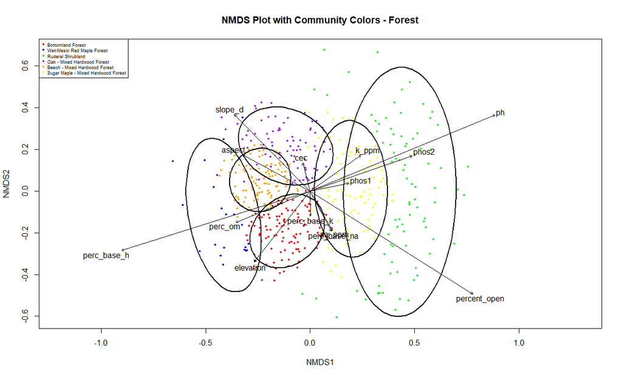

```r
vibi.forest.sub.env.grp.lev <- factor(vibi.forest.sub.env.grp$kmeans6.forest.cluster)
col <- c("red", "blue", "green", "purple", "orange", "yellow")
sit.sc <- vegan::scores(vibi.forest.sub.env.nmds, display="sites")
p <- ordiplot(vibi.forest.sub.env.nmds, type="none", main="NMDS Plot with Community Colors - Forest", choices=c(1,2))
points(sit.sc, pch=20, cex=0.8, col=col[vibi.forest.sub.env.grp.lev], bg=col[vibi.forest.sub.env.grp.lev])
ordiellipse(vibi.forest.sub.env.nmds, vibi.forest.sub.env.grp.lev, kind = "sd", conf=0.80, lwd=2, col="black")
leg.txt <- c("Bottomland Forest", "Wet-Mesic Red Maple Forest", "Ruderal Shrubland", "Oak - Mixed Hardwood Forest", "Beech - Mixed Hardwood Forest", "Sugar Maple - Mixed Hardwood Forest")

legend("topleft", leg.txt,
       pch=20, col=col[], pt.cex=0.75, cex=0.58)
vibi.forest.env.fit <- envfit(vibi.forest.sub.env.nmds, vibi.forest.env.std[,c(-5,-6,-11,-12,-17)], permu = 999, p.max = 0.01, choices = c(1, 2))
plot(vibi.forest.env.fit, col = "black", font=1)
```

#### Try some constrained ordination

#### Redundancy Analysis (RDA)

```r
vibi.forests.rda <- rda(vibi.forest.sub.env.hell ~ ., vibi.forest.env.std)
vibi.forests.rda
summary(vibi.forests.rda)
```

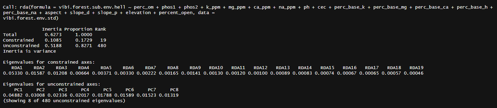

#### Triplots of the rda results (wa scores)

#### Site scores as weighted averages (vegan’s default)

#### Scaling 2 (default): correlation triplot

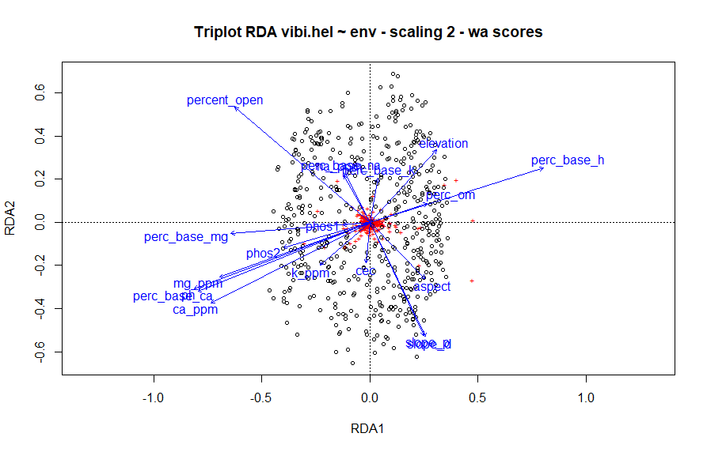

```r
plot(vibi.forests.rda, main="Triplot RDA vibi.hel ~ env - scaling 2 - wa scores")
```

## Synoptic Tables

#### Fist remove species that occur in less than 5% of plots

```r
vibi.forest.rare.removed <- vibi.combined.new.matrix.no.meadows[,colSums(vibi.combined.new.matrix.no.meadows != 0) > 31 | colnames(vibi.combined.new.matrix.no.meadows) == "TSUCAN_1" | colnames(vibi.combined.new.matrix.no.meadows) == "TSUCAN_2"]
```

#### Synoptic percentage frequency table - unordered

```r
vibi.forest.syntbl.percfreq <- syntable(vibi.forest.rare.removed, vibi.combined.new.forest.kmeans6.cluster$kmeans6.forest.cluster, abund = "percentage", type = "percfreq")
```

#### Synoptic mean abundance table - unordered

```r
vibi.forest.syntbl.meanabund <- syntable(vibi.forest.rare.removed, vibi.combined.new.forest.kmeans6.cluster$kmeans6.forest.cluster, abund = "percentage", type = "mean", digits = 5)
```

#### Synoptic percent frequency table - SORTED

```r
vibi.forest.syntbl.percfreq.sorted <- synsort(syn1 = vibi.forest.syntbl.percfreq$syntable, matrix = vibi.forest.rare.removed, cluster = vibi.combined.new.forest.kmeans6.cluster$kmeans6.forest.cluster, method = "allspec", min1 = 0)
```

#### Synoptic mean abundance table - SORTED

```r
vibi.forest.syntbl.meanabund.sorted <- synsort(syn1 = vibi.forest.syntbl.meanabund$syntable, matrix = vibi.forest.rare.removed, cluster = vibi.combined.new.forest.kmeans6.cluster$kmeans6.forest.cluster, method = "allspec", min1 = 0)
```

### Tree Species

Species code

Wet-Mesic Red Maple

Oak - Mixed Hardwood

Bottomland

Sugar Maple - Mixed Hardwood

Beech - Mixed Hardwood

Ruderal

ACERUB_2

100 (0.40306)

44 (0.08599)

15 (0.01288)

62 (0.10514)

28 (0.03805)

ACERUB_1

100 (0.44644)

76 (0.20181)

32 (0.02724)

75 (0.13462)

42 (0.05281)

PRUSER_1

58 (0.06555)

39 (0.05009)

11 (0.01537)

31 (0.03455)

38 (0.0378)

43 (0.07521)

NYSSYL_1

38 (0.04355)

24 (0.04132)

QUEPAL_2

27 (0.04297)

12 (0.02004)

SASALB_1

18 (0.02074)

12 (0.01546)

QUERUB_2

34 (0.05533)

61 (0.17843)

27 (0.04093)

49 (0.08831)

14 (0.0274)

TSUCAN_1

39 (0.19132)

QUEALB_2

10 (0.01358)

37 (0.07692)

12 (0.02612)

21 (0.02863)

TSUCAN_2

32 (0.14639)

QUERUB_1

34 (0.04999)

32 (0.08067)

27 (0.02973)

29 (0.02983)

26 (0.04024)

MAGACU_1

27 (0.02754)

16 (0.01234)

QUEALB_1

15 (0.04267)

ACENEG_1

34 (0.11209)

29 (0.06393)

ACENEG_2

24 (0.05503)

PLAOCC_2

20 (0.04925)

19 (0.03667)

15 (0.0226)

PLAOCC_1

17 (0.04321)

POPDEL_2

17 (0.06337)

15 (0.03709)

ACESAC_2

12 (0.01614)

13 (0.0368)

12 (0.01795)

ACESAR_1

68 (0.12639)

61 (0.12311)

100 (0.47673)

100 (0.4476)

37 (0.05406)

ACESAR_2

12 (0.01004)

12 (0.01197)

82 (0.27847)

77 (0.222)

14 (0.01416)

CARCOR_1

13 (0.01186)

48 (0.06139)

17 (0.01387)

26 (0.02809)

LIRTUL_1

33 (0.04673)

22 (0.02964)

30 (0.05683)

23 (0.039)

17 (0.02349)

TILAME_1

15 (0.02265)

28 (0.03299)

20 (0.0138)

11 (0.0105)

CARCOR_2

26 (0.03845)

16 (0.01487)

TILAME_2

11 (0.01212)

25 (0.02811)

14 (0.01313)

JUGNIG_2

14 (0.03323)

22 (0.02884)

14 (0.01834)

FAGGRA_1

56 (0.09304)

93 (0.34807)

48 (0.05815)

98 (0.39433)

10 (0.01136)

FAGGRA_2

51 (0.15806)

68 (0.21503)

FRAPEN_1

55 (0.10579)

15 (0.00979)

54 (0.14715)

55 (0.11468)

41 (0.05759)

84 (0.27384)

ULMAME_1

60 (0.09706)

26 (0.03531)

53 (0.08388)

27 (0.02419)

70 (0.1541)

ULMAME_2

18 (0.01583)

11 (0.01085)

19 (0.02004)

30 (0.03943)

AESGLA_1

16 (0.03846)

13 (0.02764)

21 (0.03173)

FRAAME_1

19 (0.03426)

### Small Tree Species

Species code

Wet-Mesic Red Maple

Oak - Mixed Hardwood

Bottomland

Sugar Maple - Mixed Hardwood

Beech - Mixed Hardwood

Ruderal

OSTVIR

18 (0.00281)

44 (0.02068)

34 (0.00597)

55 (0.01414)

RHACAT

15 (0.00284)

PRUVIR

12 (0.00223)

18 (0.00308)

CRPCAR

37 (0.01226)

39 (0.01302)

53 (0.01055)

54 (0.0133)

22 (0.0021)

### Shrub Species

Species code

Wet-Mesic Red Maple

Oak - Mixed Hardwood

Bottomland

Sugar Maple - Mixed Hardwood

Beech - Mixed Hardwood

Ruderal

VIBDEN

79 (0.00733)

29 (0.00147)

34 (0.00275)

33 (0.00218)

34 (0.00285)

62 (0.00292)

RUBFLA

13 (0.00156)

10 (0.00086)

VIBACE

15 (0.00133)

66 (0.01074)

16 (0.00148)

51 (0.00983)

HAMVIR

12 (0.00481)

49 (0.03041)

15 (0.00349)

32 (0.01011)

LINBEN

69 (0.05475)

39 (0.03953)

30 (0.02565)

87 (0.08015)

83 (0.04811)

59 (0.0451)

EUOALA

21 (0.0025)

33 (0.00372)

25 (0.00315)

15 (0.00087)

CORALT

24 (0.00215)

18 (0.00162)

RIBCYN

18 (0.00193)

17 (0.00103)

EUOOBO

21 (0.00169)

10 (0.00088)

53 (0.00444)

57 (0.0056)

10 (0.00053)

ROSMUL

87 (0.03394)

44 (0.00647)

78 (0.02004)

82 (0.02438)

70 (0.00958)

95 (0.05721)

LIGVUL

66 (0.01096)

15 (0.00179)

52 (0.01386)

65 (0.00947)

38 (0.00382)

85 (0.03671)

FRAALN

82 (0.024)

56 (0.00777)

49 (0.01728)

58 (0.01068)

63 (0.00473)

67 (0.03531)

LONMOR

47 (0.00666)

12 (0.0011)

43 (0.01643)

49 (0.00972)

25 (0.00225)

66 (0.01961)

LONMAA

36 (0.00523)

32 (0.02027)

37 (0.00569)

23 (0.00206)

56 (0.02641)

VIBOPU

34 (0.00252)

16 (0.00083)

30 (0.00259)

45 (0.00276)

ROSSET

19 (0.00186)

### Vine Species

Species code

Wet-Mesic Red Maple

Oak - Mixed Hardwood

Bottomland

Sugar Maple - Mixed Hardwood

Beech - Mixed Hardwood

Ruderal

SMXROT

46 (0.0109)

68 (0.01129)

13 (0.00125)

45 (0.00526)

VITRIP

24 (0.00349)

12 (0.00156)

52 (0.00923)

37 (0.00351)

16 (0.00192)

54 (0.00489)

PARQUI

89 (0.01122)

61 (0.00454)

72 (0.00768)

97 (0.01466)

88 (0.01053)

94 (0.00872)

SMXHIS

10 (0.00061)

27 (0.00177)

19 (0.00131)

TOXRAD

96 (0.02237)

71 (0.00571)

80 (0.01629)

96 (0.01216)

94 (0.00999)

100 (0.04365)

LONJAP

18 (0.00367)

12 (0.00085)

27 (0.00367)

### Herbaceous Species

Species code

Wet-Mesic Red Maple

Oak - Mixed Hardwood

Bottomland

Sugar Maple - Mixed Hardwood

Beech - Mixed Hardwood

Ruderal

LEEVIR

76 (0.03539)

39 (0.00976)

54 (0.00494)

71 (0.01029)

64 (0.0098)

75 (0.01654)

CXSWAN

73 (0.01134)

49 (0.0074)

36 (0.00399)

51 (0.0069)

27 (0.00148)

GLYSTR

72 (0.01396)

24 (0.00353)

30 (0.00467)

50 (0.00667)

34 (0.00725)

80 (0.0111)

CINARU

63 (0.01188)

22 (0.00185)

29 (0.00158)

52 (0.00499)

35 (0.00316)

65 (0.00518)

POTSIM

60 (0.00548)

22 (0.00193)

19 (0.00116)

26 (0.00178)

15 (0.00114)

44 (0.00226)

DRYCAR

50 (0.00572)

34 (0.003)

15 (0.0008)

45 (0.00398)

49 (0.00523)

41 (0.00244)

VEROFF

47 (0.00488)

20 (0.00238)

30 (0.00207)

32 (0.00329)

29 (0.00129)

CXGRCLI

33 (0.00587)

12 (0.00145)

10 (0.00051)

23 (0.00212)

21 (0.00253)

36 (0.00325)

DICIMP

24 (0.00191)

14 (0.00063)

CXDEBIR

15 (0.00316)

17 (0.00148)

10 (0.00089)

RUBHIS

13 (0.00274)

MITREP

24 (0.00283)

73 (0.00703)

11 (0.00104)

41 (0.00428)

MAICAN

16 (0.00432)

56 (0.01405)

27 (0.00268)

THENOV

14 (0.00629)

29 (0.03059)

33 (0.01981)

MNTUNI

27 (0.00232)

16 (0.00135)

CONAME

22 (0.00504)

20 (0.00267)

CXPENS

20 (0.01222)

19 (0.00333)

VERALT

58 (0.04836)

27 (0.00293)

45 (0.00942)

PHAARU

49 (0.06684)

12 (0.00145)

40 (0.04187)

SOLCAN

15 (0.00111)

12 (0.00088)

47 (0.02136)

22 (0.00141)

33 (0.0043)

VERURT

39 (0.00179)

17 (0.00102)

34 (0.00118)

BOECYL

14 (0.00108)

37 (0.01057)

15 (0.00097)

10 (0.00108)

46 (0.00277)

JUNEFF

31 (0.00304)

33 (0.00307)

15 (0.00146)

43 (0.00187)

CIRARV

32 (0.00166)

10 (0.00034)

RUMOBT

15 (0.00106)

31 (0.0013)

14 (0.001)

31 (0.00128)

SOLGIG

30 (0.00968)

13 (0.00093)

22 (0.00117)

LEEORY

11 (0.00483)

28 (0.00913)

24 (0.00976)

APOCAN

27 (0.00496)

16 (0.00101)

DICCLA

26 (0.00517)

23 (0.00122)

LYSCIL

26 (0.00186)

24 (0.0015)

26 (0.00098)

CALSEP

25 (0.0012)

HESMAT

25 (0.00116)

16 (0.00103)

19 (0.00097)

ARTVUL

23 (0.00873)

POAPRA

20 (0.01095)

EUTGRA

19 (0.00105)

17 (0.00061)

ARIDRA

18 (0.0009)

11 (0.00046)

GLEHED

18 (0.00144)

12 (0.00065)

TEUCAN

17 (0.0007)

15 (0.00072)

IMPPAL

17 (0.00111)

ERIANN

16 (0.0006)

ELYVIL

16 (0.00099)

EUPPER

15 (0.00087)

13 (0.00046)

PERPUN

14 (0.00243)

18 (0.00126)

ANTODO

11 (0.00226)

13 (0.0152)

12 (0.00241)

CIRLUT

54 (0.00441)

20 (0.00158)

51 (0.00499)

86 (0.00835)

62 (0.00735)

77 (0.00453)

SYMLAT

66 (0.00605)

34 (0.00286)

57 (0.0029)

74 (0.00705)

56 (0.00547)

88 (0.00409)

ALLPET

33 (0.0036)

17 (0.00191)

46 (0.00334)

68 (0.00726)

35 (0.00497)

61 (0.00454)

OXASTR

50 (0.00394)

15 (0.00165)

48 (0.00205)

65 (0.00622)

32 (0.00276)

79 (0.0035)

GALTFL

21 (0.00198)

17 (0.00092)

18 (0.00078)

60 (0.00589)

44 (0.00426)

40 (0.00182)

EUPRUG

40 (0.00548)

53 (0.0108)

14 (0.00179)

47 (0.0049)

ALLTRI

45 (0.00655)

29 (0.00342)

RANREC

24 (0.00116)

17 (0.00076)

44 (0.00339)

24 (0.00169)

35 (0.00139)

ELYHYS

10 (0.00076)

38 (0.00357)

14 (0.00129)

19 (0.00107)

SOLFLE

10 (0.00054)

37 (0.00392)

20 (0.00137)

GERMAC

10 (0.00079)

36 (0.00477)

27 (0.00251)

11 (0.00045)

POAALS

15 (0.00216)

15 (0.0026)

27 (0.0042)

27 (0.0022)

SENOBO

24 (0.00233)

SANCAN

24 (0.00149)

15 (0.00096)

CAUTHA

21 (0.00175)

18 (0.00163)

LAPCAN

14 (0.0019)

20 (0.00484)

ACTALB

10 (0.00028)

19 (0.00216)

21 (0.00192)

SANICAN

11 (0.00076)

19 (0.00224)

12 (0.00088)

19 (0.00092)

CXHIRT

19 (0.00202)

10 (0.00217)

CRYCAN

15 (0.001)

18 (0.00114)

12 (0.00083)

SYMCOR

17 (0.00168)

RANABO

16 (0.0009)

12 (0.00068)

ANETHA

14 (0.00097)

12 (0.00089)

PODPEL

40 (0.00665)

51 (0.006)

41 (0.00372)

77 (0.02178)

12 (0.00109)

SOLCAE

25 (0.00241)

46 (0.00381)

51 (0.00487)

55 (0.00488)

17 (0.00104)

POLPUB

11 (0.00105)

29 (0.00239)

24 (0.00103)

51 (0.00466)

POLACR

11 (0.00095)

27 (0.00324)

47 (0.00766)

51 (0.00874)

15 (0.00096)

CXDIGI

12 (0.00164)

32 (0.00436)

12 (0.00125)

42 (0.00522)

MAIRAC

11 (0.00072)

24 (0.00101)

33 (0.00225)

37 (0.00264)

EPIVIR

15 (0.00148)

36 (0.00335)

PROLAN

10 (0.00062)

27 (0.00204)

POLBIF

11 (0.00076)

22 (0.00096)

11 (0.00052)

24 (0.00165)

CALAL

11 (0.00083)

23 (0.00289)

CXLAXF

17 (0.0014)

21 (0.00278)

TIACOR

13 (0.00079)

21 (0.00208)

DRYINT

20 (0.00157)

12 (0.00101)

18 (0.00234)

BRAERE

11 (0.00058)

18 (0.0016)

GEUCAN

59 (0.0052)

17 (0.00215)

59 (0.00296)

75 (0.00584)

49 (0.00482)

81 (0.00642)

LYSNUM

18 (0.00334)

55 (0.01801)

23 (0.0019)

63 (0.01667)

JUNTEN

38 (0.00437)

27 (0.00251)

14 (0.00089)

32 (0.00283)

17 (0.00163)

52 (0.00669)

PILPUM

15 (0.00088)

43 (0.00315)

41 (0.00354)

18 (0.00115)

51 (0.00554)

PRUVUL

26 (0.0018)

22 (0.00114)

19 (0.00103)

15 (0.00148)

43 (0.00177)

SOLRUG

32 (0.00286)

23 (0.00131)

24 (0.00175)

14 (0.00126)

42 (0.00282)

AGRPAR

12 (0.00051)

31 (0.00208)

12 (0.00072)

41 (0.00446)

CXTRIB

28 (0.00297)

18 (0.00144)

39 (0.00296)

PERSAG

24 (0.00157)

27 (0.00141)

34 (0.00531)

ELYVIR

20 (0.00115)

30 (0.002)

FRAVIR

15 (0.00083)

12 (0.00041)

11 (0.00058)

29 (0.00137)

DACGLO

13 (0.00109)

14 (0.00108)

11 (0.00081)

26 (0.00157)

MICVIM

11 (0.00356)

19 (0.00265)

19 (0.01341)

10 (0.00328)

25 (0.01556)

SCULAT

15 (0.00066)

14 (0.00045)

24 (0.00079)

CXLURI

15 (0.0014)

22 (0.00508)

CXSTIP

18 (0.00097)

MYOSCO

12 (0.00144)

18 (0.00127)

DOEUMB

12 (0.00078)

11 (0.00267)

# Discussion

## Community Descriptions

### Sugar Maple – Mixed Hardwood

Compared with the Beech – Mixed Hardwood type, this forest type has significantly less American beech and is characterized by a dominance of sugar maple in both the canopy and understory. Soils supporting this type are typically richer (i.e., have higher nutrient levels) than those supporting similar beech or oak-dominated forests, and many good example are found on rich mesic slopes. Many conservation practitioners consider this part of a more broadly defined “Beech-Maple” forest type. Our analyses consistently separated this type out from the Beech - Mixed Hardwood forests and we prefer to maintain it as distinct, at least for now.

### Wet-Mesic Red Maple

These forests are characterized by dominance of red maple (Acer rubrum) in the canopy and a number of species adapted to seasonally wet conditions across all the strata. Many plots designated as this “swamp forest” type are young even-aged stands that have developed on previously drained agricultural land. In many cases the herbaceous layer is sparse, but characteristic herbaceous layer species include Carex swanii, Glyceria striata, Cinna arundinacea and Dryopteris carthusiana, among others. Soils are realtively acidic with a seasonally-high water table. In young forests of this type recovering from past disturbance, the presence of non-native earthworms is often a limiting factor for herbaceous layer development.

### Ruderal Forest and Shrubland

This could be thought of as more of a successional state than a stable community type. Dominant species are often exotic shrubs with “weedy natives” scattered throughout.

### Meadow and Marsh

Like Ruderal Shrubland, this type represented the many versions of forb and graminoid dominated “old fields” that have established in previously cleared/disturbed areas.

## Crosswalk to Natureserve Types

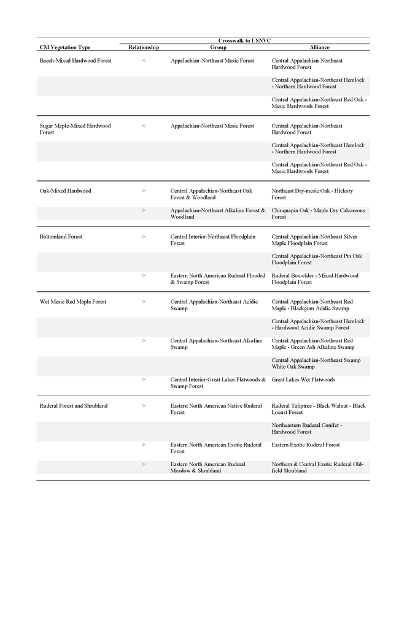